# Using SparkR with 2013 NYCTaxi Data: Data wrangling, manipulations, modeling, and evaluation

Algorithms and Data Science & R Server Teams, Microsoft Data Group

March 12, 2017

# 1 Introduction

We use Spark SQL for many of the data wrangling tasks. For plotting and visualization, small amounts of data from Spark dataframes are transformed to the local data frames.

# 2 Creating spark context and loading packages

```r
###########################################
# LOAD LIBRARIES FROM SPECIFIED PATH
###########################################
.libPaths(c(file.path(Sys.getenv("SPARK_HOME"), "R", "lib"), .libPaths()))
library(SparkR)
library(rmarkdown)
library(knitr)
library(gridExtra)
library(ggplot2)
library(ggmap)

###########################################
# CREATE SPARK CONTEXT
###########################################
sc <- sparkR.session(
  sparkPackages = "com.databricks:spark-csv_2.10:1.3.0"
)
```

```
## Launching java with spark-submit command /usr/hdp/current/spark2-client/bin/spark-submit  --packages com.databricks:spark-csv_2.10:1.3.0 sparkr-shell /tmp/RtmpO70qVB/backend_portbcbf434f8de0
```

```r
SparkR::setLogLevel("OFF")
```

```r
###########################################
## SPECIFY BASE HDFS DIRECTORY
###########################################
fullDataDir <- "/HdiSamples/HdiSamples/NYCTaxi"
```

# 3 Reading in files from HDFS (csv or parquet)

Data for this exercise can be downloaded from the public blob locations below:  
1. Trip (Csv): http://cdspsparksamples.blob.core.windows.net/data/NYCTaxi/combined_taxi_trip_w_header.csv (~19 Gb)  
2. Fare (Csv): http://cdspsparksamples.blob.core.windows.net/data/NYCTaxi/combined_taxi_fare_w_header.csv (~28 Gb)  
The data can be uploaded to the blob (or other storage) attached to your HDInsight cluster (HDFS) and used as input into the scripts shown here. The csv files can be read into Spark context and saved in parquet format. Once saved in parquet format, data can be read in much more quickly than csv files.

```r
###########################################
# TRIP FILE (CSV format, or PARQUET format)
###########################################
starttime <- Sys.time();

#tripPath <- file.path(fullDataDir, "combined_taxi_trip_w_header.csv")
#tripDF <- read.df(tripPath, source = "com.databricks.spark.csv",
#                  header = "true", inferSchema = "true")
#tripPathParquet <- file.path(fullDataDir, "CombinedTaxiTripParquet2013")
#tripDFRepartitioned <- repartition(tripDF, 20) # write.df below will produce this many files
#write.parquet(tripDFRepartitioned, tripPathParquet)

tripPathParquet <- file.path(fullDataDir, "CombinedTaxiTripParquet2013")
tripDF <- read.parquet(tripPathParquet)
head(tripDF, 3)
```

```
##                          medallion                     hack_license
## 1 BF9FD47CB82BFBAF286ED29B6323D2DF D97E9DF6E43B5E8739F737B8A25E44EC
## 2 9AEA423D30A07A1D376FB8E78C88A5E2 80E4604CCC69FC46772A38098750EC52
## 3 B7B64C41FDB012BAD7DC47343B57B887 16FCE7EEFC8B15D091CD47CF05087014
##   vendor_id rate_code store_and_fwd_flag     pickup_datetime
## 1       CMT         1                  N 2013-01-20 22:15:25
## 2       CMT         1                  N 2013-01-01 01:19:28
## 3       CMT         1                  N 2013-01-20 22:54:28
##      dropoff_datetime passenger_count trip_time_in_secs trip_distance
## 1 2013-01-20 22:26:56               1               691           2.0
## 2 2013-01-01 01:44:17               1              1489           5.2
## 3 2013-01-20 23:03:29               1               541           3.6
##   pickup_longitude pickup_latitude dropoff_longitude dropoff_latitude
## 1        -74.00253        40.73426         -73.97876         40.73656
## 2        -73.92196        40.86759         -73.96371         40.80549
## 3        -74.01291        40.71695         -73.98824         40.75993
```

```r
printSchema(tripDF)
```

```
## root
##  |-- medallion: string (nullable = true)
##  |-- hack_license: string (nullable = true)
##  |-- vendor_id: string (nullable = true)
##  |-- rate_code: integer (nullable = true)
##  |-- store_and_fwd_flag: string (nullable = true)
##  |-- pickup_datetime: timestamp (nullable = true)
##  |-- dropoff_datetime: timestamp (nullable = true)
##  |-- passenger_count: integer (nullable = true)
##  |-- trip_time_in_secs: integer (nullable = true)
##  |-- trip_distance: double (nullable = true)
##  |-- pickup_longitude: double (nullable = true)
##  |-- pickup_latitude: double (nullable = true)
##  |-- dropoff_longitude: double (nullable = true)
##  |-- dropoff_latitude: double (nullable = true)
```

```r
###########################################
# FARE FILE (CSV or PARQUET format)
###########################################
#farePath <- file.path(fullDataDir, "combined_taxi_fare_w_header.csv")
#fareDF <- read.df(farePath, source = "com.databricks.spark.csv",
#                  header = "true", inferSchema = "true")
#farePathParquet <- file.path(fullDataDir, "CombinedTaxiFareParquet2013")
#fareDFRepartitioned <- repartition(fareDF, 20) # write.df below will produce this many files
#write.parquet(fareDFRepartitioned, farePathParquet)

farePathParquet <- file.path(fullDataDir, "CombinedTaxiFareParquet2013")
fareDF <- read.parquet(farePathParquet)
SparkR::cache(fareDF); SparkR::count(fareDF);
```

```
## SparkDataFrame[medallion:string, hack_license:string, vendor_id:string, pickup_datetime:timestamp, payment_type:string, fare_amount:double, surcharge:double, mta_tax:double, tip_amount:double, tolls_amount:double, total_amount:double]
```

```
## [1] 173179759
```

```r
head(fareDF, 3)
```

```
##                          medallion                     hack_license
## 1 F003B055B21DB1BF03FF509D9843B3B0 E96ACE764A594BEF583DD0D47CB7533D
## 2 EC31C9229EB30C45371D5D2B834B5FE2 0B494DD625E182E7334E2C8BE0254EE9
## 3 4E03D87466970A4AE440B414AEFDBC5A 376334E11FA1DCD8859A1B8BC18917FD
##   vendor_id     pickup_datetime payment_type fare_amount surcharge mta_tax
## 1       CMT 2013-01-03 06:36:54          CSH         6.5       0.0     0.5
## 2       CMT 2013-01-02 16:57:51          CSH         5.0       1.0     0.5
## 3       CMT 2013-01-03 22:34:52          CSH        20.0       0.5     0.5
##   tip_amount tolls_amount total_amount
## 1          0            0          7.0
## 2          0            0          6.5
## 3          0            0         21.0
```

```r
printSchema(fareDF)
```

```
## root
##  |-- medallion: string (nullable = true)
##  |-- hack_license: string (nullable = true)
##  |-- vendor_id: string (nullable = true)
##  |-- pickup_datetime: timestamp (nullable = true)
##  |-- payment_type: string (nullable = true)
##  |-- fare_amount: double (nullable = true)
##  |-- surcharge: double (nullable = true)
##  |-- mta_tax: double (nullable = true)
##  |-- tip_amount: double (nullable = true)
##  |-- tolls_amount: double (nullable = true)
##  |-- total_amount: double (nullable = true)
```

```r
endtime <- Sys.time();
print (endtime-starttime);
```

```
## Time difference of 54.81886 secs
```

# 4 Using SparkR for data wrangling & manipulation

SparkR is an R package that provides a light-weight frontend to use Apache Spark from R. In Spark 2.0, SparkR provides a distributed data frame implementation that supports operations like selection, filtering, aggregation etc. (similar to R data frames, dplyr) but on large datasets. SparkR also provides support for distributed machine learning using MLlib.

## 4.1 Join datasets using SQL

You can register dataframes as tables in SQLContext and join using multiple columns. The following SQL also filters the data for some outliers.

```r
###########################################
# 1. REGISTER TABLES AND JOIN ON MULTIPLE COLUMNS, FILTER DATA
# 2. REGISTER JIONED TABLE
###########################################
starttime <- Sys.time();

createOrReplaceTempView(tripDF, "trip")
createOrReplaceTempView(fareDF, "fare")

trip_fareDF <-  SparkR::sql("SELECT
  f.pickup_datetime, hour(f.pickup_datetime) as pickup_hour,
  t.dropoff_datetime, hour(t.dropoff_datetime) as dropoff_hour,
  f.vendor_id, f.fare_amount, f.surcharge, f.tolls_amount,
  f.tip_amount, f.payment_type, t.rate_code,
  t.passenger_count, t.trip_distance, t.trip_time_in_secs,
  t.pickup_longitude, t.pickup_latitude, t.dropoff_longitude,
  t.dropoff_latitude
  FROM trip t, fare f
  WHERE t.medallion = f.medallion AND t.hack_license = f.hack_license
  AND t.pickup_datetime = f.pickup_datetime
  AND t.passenger_count > 0 and t.passenger_count < 8
  AND f.tip_amount >= 0 AND f.tip_amount <= 15
  AND f.fare_amount >= 1 AND f.fare_amount <= 150
  AND f.tip_amount < f.fare_amount AND t.trip_distance > 0
  AND t.trip_distance <= 40 AND t.trip_distance >= 1
  AND t.trip_time_in_secs >= 30 AND t.trip_time_in_secs <= 7200
  AND t.rate_code <= 5 AND f.payment_type in ('CSH','CRD')")
createOrReplaceTempView(trip_fareDF, "trip_fare")
SparkR::cache(trip_fareDF); SparkR::count(trip_fareDF);
```

```
## SparkDataFrame[pickup_datetime:timestamp, pickup_hour:int, dropoff_datetime:timestamp, dropoff_hour:int, vendor_id:string, fare_amount:double, surcharge:double, tolls_amount:double, tip_amount:double, payment_type:string, rate_code:int, passenger_count:int, trip_distance:double, trip_time_in_secs…
```

```
## [1] 134717727
```

```r
###########################################
# WRITE JOINED FILE IN PARQUET FORMAT IN HDFS
###########################################
#tripfarePathParquet <- file.path(fullDataDir, "CombinedTaxi_Trip_and_Fare_Parquet2013")
#tripfareDFRepartitioned <- repartition(trip_fareDF, 20) # write.df below will produce this many files
#write.parquet(tripfareDFRepartitioned, tripfarePathParquet)

###########################################
# SHOW REGISTERED TABLES
###########################################
head(SparkR::sql("show tables"))
```

```
##         tableName isTemporary
## 1 hivesampletable       FALSE
## 2            fare        TRUE
## 3            trip        TRUE
## 4       trip_fare        TRUE
```

```r
###########################################
# IF THE JOINED FILE IS SAVED, YOU CAN DIRECTLY READ IT IN
###########################################
#tripfarePathParquet <- file.path(fullDataDir, "CombinedTaxi_Trip_and_Fare_Parquet2013")
#trip_fareDF <- read.parquet(tripfarePathParquet)
#head(trip_fareDF, 3)
#printSchema(trip_fareDF)
#createOrReplaceTempView(trip_fareDF, "trip_fare")

endtime <- Sys.time();
print (endtime-starttime);
```

```
## Time difference of 1.662769 mins
```

# 5 Feature engineering using SQL

You can create new features using sQL statements. For example, you can use case statements to generate categorical features from coneunuous (numerical) ones.

```r
starttime <- Sys.time();

###########################################
# CREATE FEATURES IN SQL USING CASE STATEMENTS
###########################################
trip_fare_feat <- SparkR::sql("SELECT
    payment_type, pickup_hour, fare_amount, tip_amount,
    passenger_count, trip_distance, trip_time_in_secs,
  CASE
    WHEN (pickup_hour <= 6 OR pickup_hour >= 20) THEN 'Night'
    WHEN (pickup_hour >= 7 AND pickup_hour <= 10) THEN 'AMRush'
    WHEN (pickup_hour >= 11 AND pickup_hour <= 15) THEN 'Afternoon'
    WHEN (pickup_hour >= 16 AND pickup_hour <= 19) THEN 'PMRush'
    END as TrafficTimeBins,
  CASE
    WHEN (tip_amount > 0) THEN 1
    WHEN (tip_amount <= 0) THEN 0
    END as tipped
  FROM trip_fare")

SparkR::cache(trip_fare_feat); SparkR::count(trip_fare_feat);
```

```
## SparkDataFrame[payment_type:string, pickup_hour:int, fare_amount:double, tip_amount:double, passenger_count:int, trip_distance:double, trip_time_in_secs:int, TrafficTimeBins:string, tipped:int]
```

```
## [1] 134717727
```

```r
createOrReplaceTempView(trip_fare_feat, "trip_fare_feat")
head(trip_fare_feat, 3)
```

```
##   payment_type pickup_hour fare_amount tip_amount passenger_count
## 1          CSH           8         7.5          0               1
## 2          CRD          14        10.5          2               1
## 3          CSH           9         7.0          0               2
##   trip_distance trip_time_in_secs TrafficTimeBins tipped
## 1           1.4               401          AMRush      0
## 2           1.2               957       Afternoon      1
## 3           1.1               506          AMRush      0
```

```r
endtime <- Sys.time();
print (endtime-starttime);
```

```
## Time difference of 11.792 secs
```

# 6 Data visualization

## 6.1 Data exploration and plotting

For visualization, a small portion data will have to be sampled and brought into local memory as a data.frame object. R’s plotting functions (e.g. from those in ggplot package) can then be applied to the data.frame for visualization.

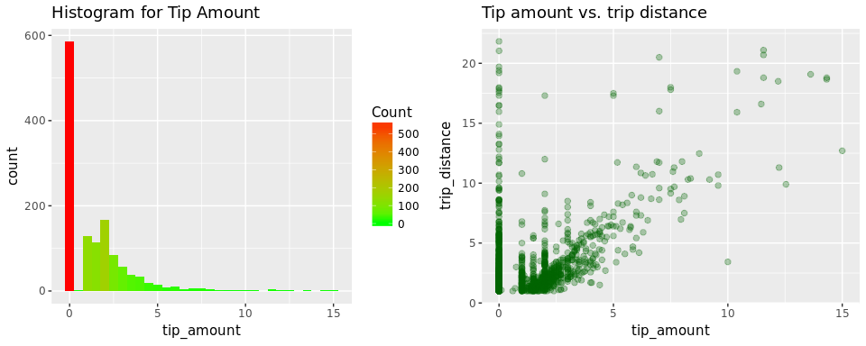

```r
starttime <- Sys.time();

###########################################
# SAMPLE SMALL PORTION OF DATA
###########################################
trip_fare_featSampled <- SparkR::sample(trip_fare_feat, withReplacement=FALSE,
                                fraction=0.00001, seed=123)

###########################################
# CONVERT SPARK DF TO LOCAL DATA.FRAME IN MEMORY OF R-SERVER EDGE NODE
###########################################
trip_fare_featSampledDF <- as.data.frame(trip_fare_featSampled);

###########################################
# Generate HISTOGRAM OF TIP AMOUNT
###########################################
hist <- ggplot(trip_fare_featSampledDF, aes(x=tip_amount)) +
  geom_histogram(binwidth = 0.5, aes(fill = ..count..)) +
  scale_fill_gradient("Count", low = "green", high = "red") +
  labs(title="Histogram for Tip Amount");

###########################################
# Generate Scatter Plot OF TRIP DISTANCE vs. TIP AMOUNT
###########################################
scatter <- ggplot(trip_fare_featSampledDF, aes(tip_amount, trip_distance)) +
  geom_point(col='darkgreen', alpha=0.3, pch=19, cex=2) +
  labs(title="Tip amount vs. trip distance");

###########################################
# Plot Histogram and Scatter Plot OF TIP AMOUNT Side by Side
###########################################
grid.arrange(hist, scatter, ncol=2)
```

```r
endtime <- Sys.time();
print (endtime-starttime);
```

```
## Time difference of 2.555724 secs
```

## 6.2 Advanced SQL summarization and plotting:

### 6.2.1 Trips in NYC area during rush and non-rush hours

This section shows more examples of SQL and advanced plotting and visualization, using ggmap. We plot the number of trips by day of the month, as well as number of trips on the NY City map during rush and non-rush hours.

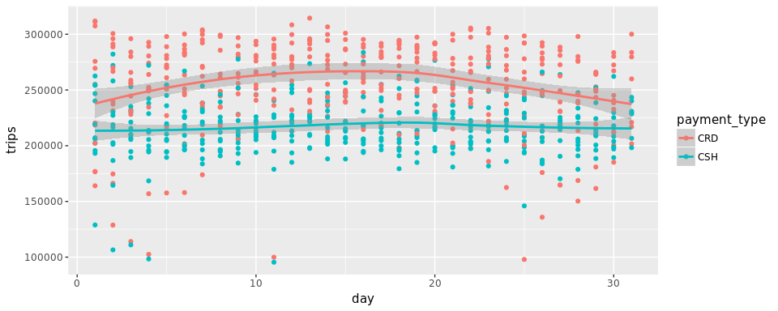

```r
starttime <- Sys.time();

###########################################
# GROUP TRIPS BY YEAR, MONTH, DAY, PAYMENT TYPE
###########################################
trip_stats_by_day <- SparkR::sql("select
      year(pickup_datetime) as year, month(pickup_datetime) as month,
      day(pickup_datetime) as day, payment_type, count(1) as trips
      from fare
      where payment_type in ('CSH','CRD')
      group by year(pickup_datetime), month(pickup_datetime),
      day(pickup_datetime), payment_type")
tsbd <- as.data.frame(trip_stats_by_day)

###########################################
# PLOT NUMBER OF TRIPS BY DAY IN DEC 2013
###########################################
ggplot(data=tsbd, aes(day, trips)) + geom_point(aes(color=payment_type)) + geom_smooth(aes(color=payment_type))
```

[figure not shown]

```r
###########################################
# PLOT TAXI PICKUPS BY HOUR TRAFFIC AND NON-TRAFFIC
###########################################
library(ggmap);
# Now, for the mapping of the rides; first we get the map
nyc_geocode <- geocode("New York City")
nyc_map13 <- get_map(location=c(nyc_geocode$lon, nyc_geocode$lat), zoom=13)

trips_2014_June_18_5am <- SparkR::sql("select * from trip_fare where hour(pickup_datetime) = 5 and day(pickup_datetime) = 11 and month(pickup_datetime) = 12 and year(pickup_datetime) = 2013 and trip_distance > 2")
trips_2014_June_18_5amDF <- as.data.frame(trips_2014_June_18_5am)
map1 <- ggmap(nyc_map13) + geom_point(data=trips_2014_June_18_5amDF, aes(pickup_longitude, pickup_latitude), color="darkred", alpha=0.04)


trips_2014_June_18_5pm <- SparkR::sql("select * from trip_fare where hour(pickup_datetime) = 17 and day(pickup_datetime) = 11 and month(pickup_datetime) = 12 and year(pickup_datetime) = 2013 and trip_distance > 2")
trips_2014_June_18_5pmDF <- as.data.frame(trips_2014_June_18_5pm)
map2 <- ggmap(nyc_map13) + geom_point(data=trips_2014_June_18_5pmDF, aes(pickup_longitude, pickup_latitude), color="darkred", alpha=0.04)

grid.arrange(map1, map2, ncol=2)
```

```r
endtime <- Sys.time();
print (endtime-starttime);
```

```
## Time difference of 41.96943 secs
```

### 6.2.2 Net efflux from NY City during AM and PM rush hours

This section examples of advanced SQL, as well as plotting. Nex efflux is shown on NY City maps during morning and evening rush hours.

[figure not shown]

```r
starttime <- Sys.time();

###########################################
# PLOT MORNING EFFLUX AT 8 AM
###########################################
morning_efflux <- SparkR::sql("select lon, lat,
      sum(flux) as net_flux from
      (select round(pickup_longitude, 3) as lon,
      round(pickup_latitude, 3) as lat, count(1) flux
      from trip_fare
      where hour(pickup_datetime) = 8 and
      day(pickup_datetime) = 11 and
      month(pickup_datetime) = 12 and
      year(pickup_datetime) = 2013
      and trip_distance > 2
      group by round(pickup_longitude, 3), round(pickup_latitude, 3)
      union all
      select round(pickup_longitude, 3) as lon,
      round(pickup_latitude, 3) as lat, count(1) * -1 flux
      from trip_fare
      where hour(dropoff_datetime) = 8 and
      day(dropoff_datetime) = 11 and
      month(dropoff_datetime) = 12 and year(dropoff_datetime) = 2013
      and trip_distance > 2
      group by round(pickup_longitude, 3), round(pickup_latitude, 3)
      ) piecewise_flux
      group by lon, lat")
morning_effluxDF <- as.data.frame(morning_efflux)
map1 <- ggmap(nyc_map13) + geom_point(data=morning_effluxDF, aes(lon, lat, color=net_flux), alpha = 0.4, size=0.5) + scale_color_continuous(low="blue", high="red")


###########################################
# PLOT EVENIG EFFLUX AT 6 PM
###########################################
evening_efflux <- SparkR::sql("select lon, lat, sum(flux) as net_flux from
      (select round(pickup_longitude, 3) as lon,
      round(pickup_latitude, 3) as lat, count(1) flux
      from trip_fare
      where hour(pickup_datetime) = 18 and
      day(pickup_datetime) = 11 and
      month(pickup_datetime) = 12 and
      year(pickup_datetime) = 2013
      and trip_distance > 2
      group by round(pickup_longitude, 3), round(pickup_latitude, 3)
      union all
      select round(pickup_longitude, 3) as lon,
      round(pickup_latitude, 3) as lat, count(1) * -1 flux
      from trip_fare
      where hour(dropoff_datetime) = 18 and
      day(dropoff_datetime) = 11 and
      month(dropoff_datetime) = 12 and year(dropoff_datetime) = 2013
      and trip_distance > 2
      group by round(pickup_longitude, 3), round(pickup_latitude, 3)
      ) piecewise_flux
      group by lon, lat")
evening_efflux <- as.data.frame(evening_efflux)
map2 <- ggmap(nyc_map13) + geom_point(data=evening_efflux, aes(lon, lat, color=net_flux), alpha = 0.4, size=0.5) + scale_color_continuous(low="red", high="darkgreen")

grid.arrange(map1, map2, ncol=2)
```

```r
endtime <- Sys.time();
print (endtime-starttime);
```

```
## Time difference of 8.644903 secs
```

# 7 Modeling with SparkR

## 7.1 Down-sampling data for modeling

```r
starttime <- Sys.time();

###########################################
# SAMPLE DATA FOR MODELING
###########################################
trip_fare_featSampled <- sample(trip_fare_feat, withReplacement=FALSE,
                                fraction=1, seed=123)
SparkR::cache(trip_fare_featSampled); SparkR::count(trip_fare_featSampled);
```

```
## SparkDataFrame[payment_type:string, pickup_hour:int, fare_amount:double, tip_amount:double, passenger_count:int, trip_distance:double, trip_time_in_secs:int, TrafficTimeBins:string, tipped:int]
```

```
## [1] 134717727
```

```r
createOrReplaceTempView(trip_fare_featSampled, "trip_fare_featSampled")

endtime <- Sys.time();
print (endtime-starttime);
```

```
## Time difference of 10.95969 secs
```

## 7.2 Partition data into train/test

```r
starttime <- Sys.time();

###########################################
# PARTITION DATA INTO TRAIN-TEST USIN SQL
###########################################
dfrand <- SparkR::sql("SELECT *, RAND() as randnum from trip_fare_featSampled" );
trainDF <- SparkR::filter(dfrand, dfrand$randnum <= 0.7)
testDF <- SparkR::filter(dfrand, dfrand$randnum > 0.7)
```

## 7.3 Create a SparkR::glm model

Train a glm model.

```r
starttime <- Sys.time();

###########################################
## CREATE GLM MODEL
###########################################
model <- SparkR::spark.glm(tip_amount ~ payment_type + pickup_hour +
                    fare_amount + passenger_count + trip_distance +
                    trip_time_in_secs + TrafficTimeBins,
                    data = trainDF, family = "gaussian",
                    tol = 1e-05, maxIter = 10)
print (summary(model));
```

```
##
## Deviance Residuals:
## (Note: These are approximate quantiles with relative error <= 0.01)
##      Min        1Q    Median        3Q       Max
## -15.5785   -0.4975    0.0801    0.5400   12.4203
##
## Coefficients:
##                            Estimate   Std. Error  t value  Pr(>|t|)
## (Intercept)                -1.3068    0.00049975  -2614.9  0
## payment_type_CRD           2.6036     0.00026795  9716.6   0
## pickup_hour                0.0038033  2.1923e-05  173.48   0
## fare_amount                0.074737   5.7425e-05  1301.5   0
## passenger_count            -0.010062  9.593e-05   -104.89  0
## trip_distance              0.073362   0.00012939  567      0
## trip_time_in_secs          2.028e-05  4.8496e-07  41.819   0
## TrafficTimeBins_Night      -0.011814  0.00040895  -28.888  0
## TrafficTimeBins_Afternoon  0.030689   0.00043639  70.326   0
## TrafficTimeBins_PMRush     0.0403     0.00047819  84.275   0
##
## (Dispersion parameter for gaussian family taken to be 1.649992)
##
##     Null deviance: 415824234  on 94298045  degrees of freedom
## Residual deviance: 155590991  on 94298036  degrees of freedom
## AIC: 314827939
##
## Number of Fisher Scoring iterations: 1
```

```r
endtime <- Sys.time();
print (endtime-starttime);
```

```
## Time difference of 2.038898 mins
```

## 7.4 Evaluate predictions on test set

```r
starttime <- Sys.time();

###########################################
## PREDICT ON TEST SET, AND EVALUATE ACCURACY
###########################################
predictions <- SparkR::predict(model, newData = testDF)
predfilt <- SparkR::select(predictions, c("label","prediction"))
SparkR::cache(predfilt); SparkR::count(predfilt);
```

```
## SparkDataFrame[label:double, prediction:double]
```

```
## [1] 40419681
```

```r
## SAMPLE PREDICTIONS FOR EVALUATION USINGS R DATAFRAME
predfiltSampled <- sample(predfilt, withReplacement=FALSE,
                                fraction=0.0001, seed=123)
predfilt_local <- as.data.frame(predfiltSampled)

# EVALUATE AND PLOT PREDICTIONS (R-sqr)
Rsqr = cor(predfilt_local$label, predfilt_local$prediction)^2; Rsqr;
```

```
## [1] 0.626165
```

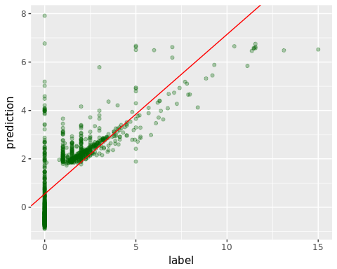

```r
# Sample predictions for plotting
predictedSampled <- predfilt_local[base::sample(1:nrow(predfilt_local), 1000),]

# Plot predicted vs. actual values
lm_model <- lm(prediction ~ label, data = predictedSampled)
ggplot(predictedSampled, aes(label, prediction)) + geom_point(col='darkgreen', alpha=0.3, pch=19, cex=1.5)   + geom_abline(aes(slope = summary(lm_model)$coefficients[2,1], intercept = summary(lm_model)$coefficients[1,1]), color = "red")
```

```r
endtime <- Sys.time();
print (endtime-starttime);
```

```
## Time difference of 8.006647 secs
```

# 8 Save data & model

## 8.1 Save model for deployment

```r
starttime <- Sys.time();

###########################################
## SAVE MODEL [REMOVE FILE IF IT EXISTS]
###########################################
if (length(system("hadoop fs -ls /HdiSamples/HdiSamples/NYCTaxi/SparkGlmModel", intern=TRUE))>=1) {
  system("hadoop fs -rm -r /HdiSamples/HdiSamples/NYCTaxi/SparkGlmModel")
}
modelPath =  file.path(fullDataDir, "SparkGlmModel");
write.ml(model, modelPath)
```

## 8.2 Save predictions to CSV

```r
starttime <- Sys.time();

###########################################
## REPARTITION DATA FOR SAVING, AND WRITE TO CSV
###########################################
predictFile <- file.path(fullDataDir, "SparkRGLMPredictions")
predfiltRepartition <- repartition(predfilt, 10)

write.df(df=predfiltRepartition, path=predictFile,
        source = "com.databricks.spark.csv",
        mode = "overwrite")

endtime <- Sys.time();
print (endtime-starttime);
```

```
## Time difference of 9.598252 secs
```

## 8.3 Save joined and sampled data

Repartition the data in specific number of chunks and save

```r
starttime <- Sys.time();

###########################################
# REPARTITION DATA FOR SAVING, AND WRITE TO PARQUET FILE
###########################################
joinedFilePath <- file.path(fullDataDir, "NYCjoinedParquetSubset")

trip_fare_featSampledRepartitioned <- repartition(trip_fare_feat, 10) # write.df below will produce this many files
write.df(df=trip_fare_featSampledRepartitioned,
         path=joinedFilePath,
         source="parquet", mode="overwrite")


endtime <- Sys.time();
print (endtime-starttime);
```

```
## Time difference of 37.85903 secs
```

# 9 Clear cache and exit

```r
###########################################
# UNPERSIST CACHED DATA FRAMES
###########################################
SparkR::unpersist(fareDF)
```

```
## SparkDataFrame[medallion:string, hack_license:string, vendor_id:string, pickup_datetime:timestamp, payment_type:string, fare_amount:double, surcharge:double, mta_tax:double, tip_amount:double, tolls_amount:double, total_amount:double]
```

```r
SparkR::unpersist(trip_fareDF)
```

```
## SparkDataFrame[pickup_datetime:timestamp, pickup_hour:int, dropoff_datetime:timestamp, dropoff_hour:int, vendor_id:string, fare_amount:double, surcharge:double, tolls_amount:double, tip_amount:double, payment_type:string, rate_code:int, passenger_count:int, trip_distance:double, trip_time_in_secs…
```

```r
SparkR::unpersist(trip_fare_feat)
```

```
## SparkDataFrame[payment_type:string, pickup_hour:int, fare_amount:double, tip_amount:double, passenger_count:int, trip_distance:double, trip_time_in_secs:int, TrafficTimeBins:string, tipped:int]
```

```r
SparkR::unpersist(trip_fare_featSampled)
```

```
## SparkDataFrame[payment_type:string, pickup_hour:int, fare_amount:double, tip_amount:double, passenger_count:int, trip_distance:double, trip_time_in_secs:int, TrafficTimeBins:string, tipped:int]
```

```r
SparkR::unpersist(predfilt)
```

```
## SparkDataFrame[label:double, prediction:double]
```

```r
###########################################
# STOP SPARKR CONTEXT
###########################################
sparkR.stop()
```

# 10 Summary

The examples shown here can be adopted to fit other data exploration and modeling scenarios having different data-types or prediction tasks (e.g. classification).